# NEON ForestAGB — Tree Growth Rate Analysis

plant_scaling_data project

2026-05-02

# 1 Overview

This document derives individual-tree growth rates from the **NEON ForestAGB** longitudinal dataset. The same tagged trees (`individualID`) are measured across multiple years, enabling computation of:

- **Annual DBH increment** (cm yr⁻¹): diameter growth between consecutive censuses
- **Annual AGB increment** (kg yr⁻¹): biomass growth between consecutive censuses
- **Relative growth rate (RGR)**: proportional diameter or biomass change per year
- **Lifetime totals**: cumulative change from first to last live census per tree

> **AGB caveat:** Biomass is estimated from DBH via Chojnacky et al. (2014) allometric equations. AGB increments are therefore *model-derived* and correlated with DBH increments — they do not represent independent measurements.

> **⚠ Growth rates can be negative** (measurement error, bark loss, or DBH measured at different heights across visits). Negative values are retained as data but flagged in relevant plots.

# 2 Dataset summary

```r
kable(data.frame(
  Metric = c(
    "Total raw live-status rows",
    "Live individuals with >= 1 census",
    "Live individuals with >= 2 censuses (growth derivable)",
    "Annual growth intervals computed",
    "Year range",
    "Sites"
  ),
  Value = c(
    format(nrow(live_raw), big.mark = ","),
    format(length(unique(live_raw$individualID)), big.mark = ","),
    format(nrow(lifetime), big.mark = ","),
    format(nrow(annual_growth), big.mark = ","),
    paste0(min(live_raw$year, na.rm=TRUE), "\u2013", max(live_raw$year, na.rm=TRUE)),
    length(neon_sites)
  ),
  stringsAsFactors = FALSE
), caption = "NEON growth analysis — dataset scope")
```

NEON growth analysis — dataset scope

| Metric | Value |
| --- | --- |
| Total raw live-status rows | 122,272 |
| Live individuals with >= 1 census | 44,409 |
| Live individuals with >= 2 censuses (growth derivable) | 27,969 |
| Annual growth intervals computed | 75,657 |
| Year range | 2014–2023 |
| Sites | 23 |

# 3 Census visit distribution

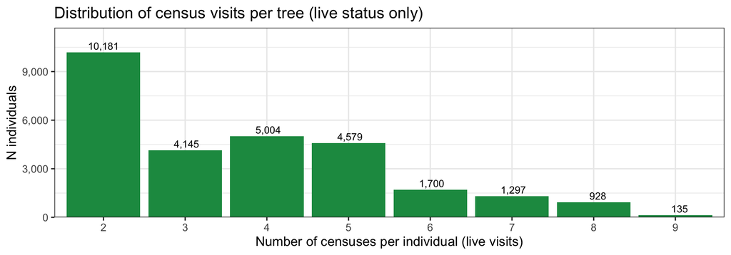

```r
lifetime |>
  count(n_census) |>
  ggplot(aes(x = factor(n_census), y = n)) +
  geom_col(fill = "#1a9850") +
  geom_text(aes(label = format(n, big.mark=",")), vjust = -0.4, size = 3.5) +
  scale_y_continuous(labels = comma, expand = expansion(mult = c(0, 0.15))) +
  labs(x = "Number of censuses per individual (live visits)",
       y = "N individuals",
       title = "Distribution of census visits per tree (live status only)")
```

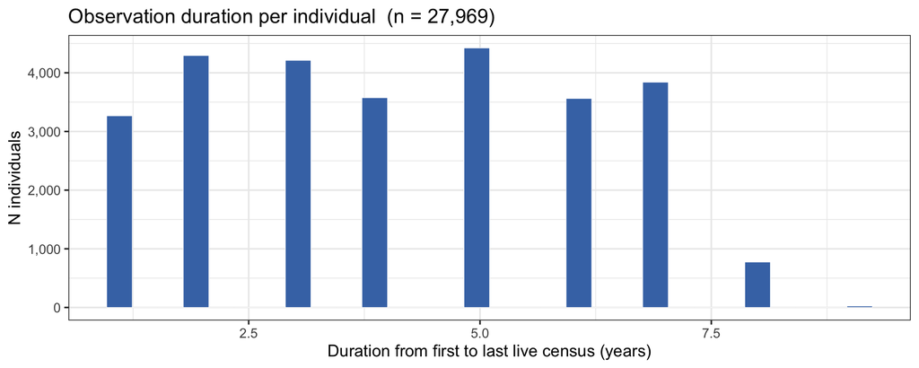

```r
lifetime |>
  ggplot(aes(x = duration_yr)) +
  geom_histogram(bins = 30, fill = "#4575b4", color = "white", linewidth = 0.2) +
  scale_y_continuous(labels = comma) +
  labs(x = "Duration from first to last live census (years)",
       y = "N individuals",
       title = paste0("Observation duration per individual  (n = ",
                      format(nrow(lifetime), big.mark=","), ")"))
```

# 4 Annual DBH increment

## 4.1 Distribution

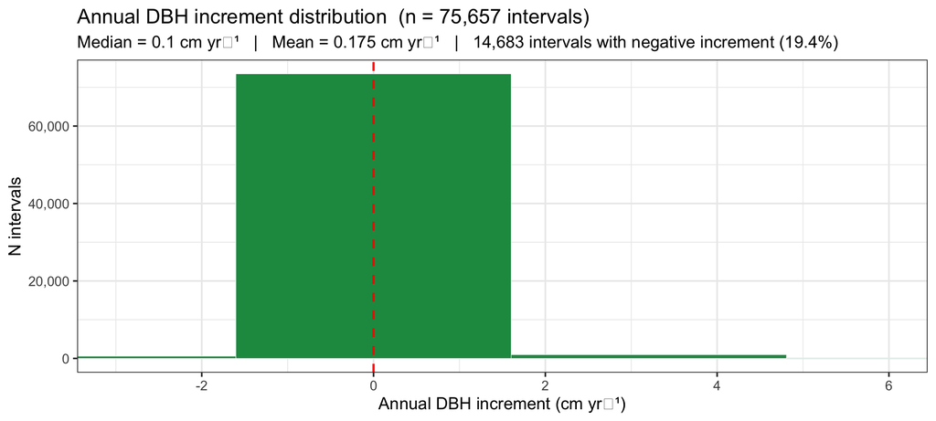

```r
annual_growth |>
  ggplot(aes(x = DBH_inc_cm_yr)) +
  geom_histogram(bins = 80, fill = "#1a9850", color = "white", linewidth = 0.15) +
  geom_vline(xintercept = 0, color = "red", linetype = "dashed", linewidth = 0.8) +
  scale_y_continuous(labels = comma) +
  coord_cartesian(xlim = c(-3, 6)) +
  labs(
    x = "Annual DBH increment (cm yr\u207b\u00b9)",
    y = "N intervals",
    title = paste0("Annual DBH increment distribution  (n = ",
                   format(nrow(annual_growth), big.mark=","), " intervals)"),
    subtitle = paste0(
      "Median = ",
      round(median(annual_growth$DBH_inc_cm_yr, na.rm=TRUE), 3),
      " cm yr\u207b\u00b9   |   Mean = ",
      round(mean(annual_growth$DBH_inc_cm_yr, na.rm=TRUE), 3),
      " cm yr\u207b\u00b9   |   ",
      format(sum(annual_growth$DBH_inc_cm_yr < 0, na.rm=TRUE), big.mark=","),
      " intervals with negative increment (",
      round(100*mean(annual_growth$DBH_inc_cm_yr < 0, na.rm=TRUE), 1), "%)"
    )
  )
```

## 4.2 Annual DBH increment vs initial DBH

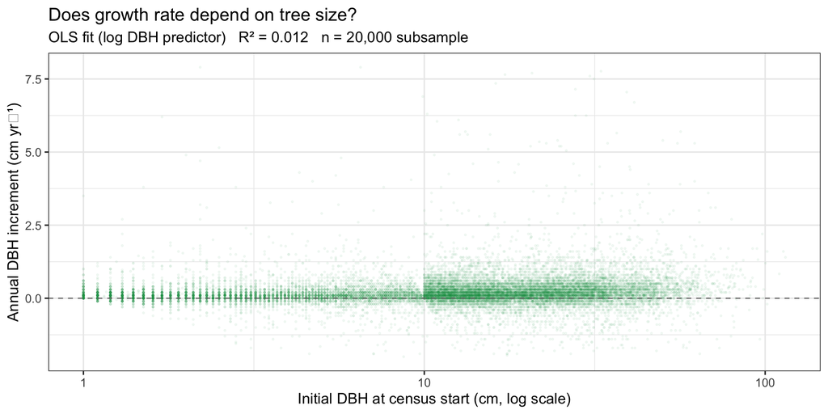

```r
sub <- annual_growth |>
  filter(!is.na(DBH_start), DBH_start > 0,
         !is.na(DBH_inc_cm_yr),
         DBH_inc_cm_yr > -2, DBH_inc_cm_yr < 8) |>
  sample_n(min(20000, n()))

lm_dbhinc <- lm(DBH_inc_cm_yr ~ log(DBH_start), data = sub)
r2_dbhinc  <- round(summary(lm_dbhinc)$r.squared, 3)

ggplot(sub, aes(x = DBH_start, y = DBH_inc_cm_yr)) +
  geom_point(alpha = 0.05, size = 0.5, color = "#1a9850") +
  geom_smooth(method = "lm", formula = y ~ log(x),
              color = "#d73027", linewidth = 1.2, se = TRUE) +
  geom_hline(yintercept = 0, linetype = "dashed", color = "grey50") +
  scale_x_log10(labels = comma) +
  labs(
    x = "Initial DBH at census start (cm, log scale)",
    y = "Annual DBH increment (cm yr\u207b\u00b9)",
    title = "Does growth rate depend on tree size?",
    subtitle = paste0("OLS fit (log DBH predictor)   R\u00b2 = ", r2_dbhinc,
                      "   n = 20,000 subsample")
  )
```

## 4.3 Annual DBH increment by site

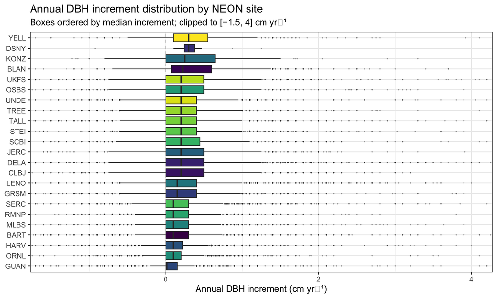

```r
annual_growth |>
  filter(!is.na(DBH_inc_cm_yr)) |>
  group_by(siteID) |>
  mutate(med = median(DBH_inc_cm_yr, na.rm=TRUE)) |>
  ungroup() |>
  ggplot(aes(x = reorder(siteID, med), y = DBH_inc_cm_yr, fill = siteID)) +
  geom_boxplot(outlier.size = 0.3, outlier.alpha = 0.3, show.legend = FALSE,
               coef = 1.5) +
  geom_hline(yintercept = 0, linetype = "dashed", color = "grey40") +
  coord_flip(ylim = c(-1.5, 4)) +
  scale_fill_viridis_d(option = "D") +
  labs(
    x = NULL,
    y = "Annual DBH increment (cm yr\u207b\u00b9)",
    title = "Annual DBH increment distribution by NEON site",
    subtitle = "Boxes ordered by median increment; clipped to [\u22121.5, 4] cm yr\u207b\u00b9"
  )
```

## 4.4 Annual DBH increment per-site statistics

```r
site_stats <- annual_growth |>
  filter(!is.na(DBH_inc_cm_yr)) |>
  group_by(siteID) |>
  summarise(
    N_intervals  = n(),
    Mean_cm_yr   = round(mean(DBH_inc_cm_yr, na.rm=TRUE), 3),
    Median_cm_yr = round(median(DBH_inc_cm_yr, na.rm=TRUE), 3),
    SD_cm_yr     = round(sd(DBH_inc_cm_yr, na.rm=TRUE), 3),
    P10_cm_yr    = round(quantile(DBH_inc_cm_yr, 0.10, na.rm=TRUE), 3),
    P90_cm_yr    = round(quantile(DBH_inc_cm_yr, 0.90, na.rm=TRUE), 3),
    Pct_negative = round(100*mean(DBH_inc_cm_yr < 0, na.rm=TRUE), 1),
    .groups = "drop"
  ) |>
  arrange(desc(Median_cm_yr))

kable(site_stats,
      col.names = c("Site","N intervals","Mean (cm/yr)","Median (cm/yr)",
                    "SD","P10","P90","% negative"),
      caption = "Annual DBH increment summary per NEON site")
```

Annual DBH increment summary per NEON site

| Site | N intervals | Mean (cm/yr) | Median (cm/yr) | SD | P10 | P90 | % negative |
| --- | --- | --- | --- | --- | --- | --- | --- |
| DSNY | 20 | 0.316 | 0.300 | 0.389 | 0.167 | 0.515 | 5.0 |
| YELL | 628 | 0.352 | 0.300 | 1.245 | -0.165 | 1.000 | 16.1 |
| KONZ | 105 | 0.409 | 0.250 | 1.736 | -0.720 | 1.460 | 20.0 |
| BLAN | 899 | 0.376 | 0.225 | 0.625 | -0.100 | 1.110 | 12.2 |
| CLBJ | 1941 | 0.235 | 0.200 | 0.950 | -0.300 | 0.950 | 23.5 |
| DELA | 4782 | 0.264 | 0.200 | 1.723 | -0.200 | 1.000 | 18.0 |
| JERC | 1359 | 0.261 | 0.200 | 2.020 | -0.200 | 0.900 | 22.0 |
| OSBS | 2310 | 0.202 | 0.200 | 1.838 | -0.300 | 0.800 | 22.5 |
| SCBI | 2342 | 0.220 | 0.200 | 1.644 | -0.300 | 0.900 | 21.4 |
| STEI | 4162 | 0.235 | 0.200 | 0.812 | -0.100 | 0.700 | 14.9 |
| TALL | 3139 | 0.194 | 0.200 | 1.554 | -0.400 | 0.800 | 24.5 |
| TREE | 4527 | 0.206 | 0.200 | 1.121 | -0.200 | 0.700 | 17.2 |
| UKFS | 3550 | 0.141 | 0.200 | 3.813 | -0.300 | 0.900 | 22.6 |
| UNDE | 4389 | 0.193 | 0.200 | 1.909 | -0.100 | 0.600 | 15.3 |
| GRSM | 4095 | 0.174 | 0.150 | 2.003 | -0.200 | 0.700 | 20.7 |
| LENO | 2722 | 0.262 | 0.150 | 0.990 | -0.200 | 0.900 | 19.5 |
| BART | 8604 | 0.105 | 0.100 | 1.223 | -0.200 | 0.500 | 20.0 |
| HARV | 8289 | 0.109 | 0.100 | 0.859 | -0.200 | 0.400 | 21.1 |
| MLBS | 4006 | 0.147 | 0.100 | 0.935 | -0.200 | 0.500 | 20.4 |
| ORNL | 4682 | 0.115 | 0.100 | 1.109 | -0.100 | 0.400 | 19.9 |
| RMNP | 2348 | 0.175 | 0.100 | 0.794 | -0.150 | 0.500 | 16.3 |
| SERC | 4784 | 0.184 | 0.100 | 1.339 | -0.100 | 0.600 | 15.6 |
| GUAN | 1974 | 0.044 | 0.017 | 1.753 | -0.200 | 0.362 | 22.0 |